# Data visualisation DA 2

## Digital Assessment 2

Data visualisation CSE3020

Name: Makesh Srinivasan  
Registration number: 19BCE1717  
Course code: CSE3020  
Faculty: Prof. Parvathi  
Slot: F1 + TF1  
Date: 12-April-2021 Tuesday

**Topic:** Multivariate data analysis

**Instructions:**

1. Define Multivariate Data
2. Example of Multivariate Data with case study
3. Different Visualization can be used for Multivariate Data (Mention 5 different visualisation)
4. Implement the same using python or R using the same case study given in point no 2
5. Give the dataset link and coding (co-lab link or GitHub link)
6. Conclusion

**Table of contents:**  
1) Libraries  
2) Parallel coordinates  
3) Scatter plot matrix  
4) Chernoff faces  
5) Star plots  
6) Pixel oriented representation

**Introduction**  
For this digital assessment, I have chosen to work with the FIFA18 dataset from Kaggle. The link is provided below.

**Dataset description:**  
The dataset contains: -> Every player featuring in FIFA 18  
-> 70+ attributes  
-> Player and Flag Images  
-> Playing Position Data  
-> Attributes based on actual data of the latest EA's FIFA 18 game  
-> Attributes include on all player style statistics like Dribbling, Aggression, GK Skills etc.  
-> Player personal data like Nationality, Photo, Club, Age, Wage, Salary etc.

**Link:** https://www.kaggle.com/datasets/thec03u5/fifa-18-demo-player-dataset

Let us now see the various plots discussed in the report.

### Libraries

```python
import pandas as pd
import re
import numpy as np
from pandas.plotting import parallel_coordinates
import plotly.express as px
import plotly as plt
import plotly.graph_objs as go
plt.offline.init_notebook_mode(connected = True)
import matplotlib
import matplotlib.pyplot as plt
%matplotlib inline
import seaborn as sns
import os
```

### 1) Parallel coordinates

**Preprocessing**

```python
pd.set_option('max_columns', None)
df = pd.read_csv("CompleteDataset.csv", index_col=0)
footballers = df.copy()
footballers['Unit'] = df['Value'].str[-1]
footballers['Value (M)'] = np.where(footballers['Unit'] == '0', 0, footballers['Value'].str[1:-1].replace(r'[a-zA-Z]',''))
footballers['Value (M)'] = footballers['Value (M)'].astype(float)
footballers['Value (M)'] = np.where(footballers['Unit'] == 'M', footballers['Value (M)'], footballers['Value (M)']/1000)
footballers = footballers.assign(Value=footballers['Value (M)'], Position=footballers['Preferred Positions'].str.split().str[0])
```

#### Plot

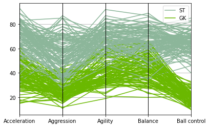

```python
f = (footballers.iloc[:, 12:17].loc[footballers['Position'].isin(['ST', 'GK'])].applymap(lambda v: int(v) if str.isdecimal(v) else np.nan).dropna())
f['Position'] = footballers['Position']
f = f.sample(200)
parallel_coordinates(f, 'Position')
```

**INFERENCE:**  
Here, we see that the lines have a good positive relation and negative relations between the attributes (1) Acceleration, (2) aggression, (3) agility, (4) balance and (5) ball control. There is positive relation between the following pairs of attributes: (1,2), (3,4), (4,5) while negative relation for the pair (2,3). This trend is similar for both classes - GK and ST (goal keeper and striker). However, the magnitude of the correlation varies between the two for the attributes.

### 2) Scatterplot matrix

**Plot**

```python
footballers_subset = footballers.iloc[:, 11:18]
footballers_subset
fig = px.scatter_matrix(footballers_subset)
fig.show()
```

[interactive chart not shown]

**INFERENCE:**  
In the scatter plot matrix, we see that the plots ae seemingly random at first glance. When we take a deeper look, we notice that the lines formed by 2 distinct attributes are in fact positively related and fairly linear. The reason why it is not clear is due to the size of the markers being too large in addition to multiple outliers found in the dataset. There are over 17000 rows and thus, even a few hundred outliers can cause the visualisation to look dense and convoluted.  
Almost all attributes are positively correlated and a few are negatively correlated (when the graph trend seems to move downward). The magnitude of correlation is between -1 and +1 with the negative extreme to be perfect negative correlation while the positive extreme is perfect positive correlation. The plots where there is no trend observed, the correlation value is closer to 0.

### 3) Chernoff faces

**Preprocessing**

```python
footballers_s2 = footballers.iloc[:,11:29]
footballers_s2.head()
```

|  | Special | Acceleration | Aggression | Agility | Balance | Ball control | Composure | Crossing | Curve | Dribbling | Finishing | Free kick accuracy | GK diving | GK handling | GK kicking | GK positioning | GK reflexes | Heading accuracy |
| --- | --- | --- | --- | --- | --- | --- | --- | --- | --- | --- | --- | --- | --- | --- | --- | --- | --- | --- |
| 0 | 2228 | 89 | 63 | 89 | 63 | 93 | 95 | 85 | 81 | 91 | 94 | 76 | 7 | 11 | 15 | 14 | 11 | 88 |
| 1 | 2154 | 92 | 48 | 90 | 95 | 95 | 96 | 77 | 89 | 97 | 95 | 90 | 6 | 11 | 15 | 14 | 8 | 71 |
| 2 | 2100 | 94 | 56 | 96 | 82 | 95 | 92 | 75 | 81 | 96 | 89 | 84 | 9 | 9 | 15 | 15 | 11 | 62 |
| 3 | 2291 | 88 | 78 | 86 | 60 | 91 | 83 | 77 | 86 | 86 | 94 | 84 | 27 | 25 | 31 | 33 | 37 | 77 |
| 4 | 1493 | 58 | 29 | 52 | 35 | 48 | 70 | 15 | 14 | 30 | 13 | 11 | 91 | 90 | 95 | 91 | 89 | 25 |

```python
import matplotlib
matplotlib.use('Agg')
import matplotlib.pyplot as plt

from numpy.random import rand
from numpy import pi, arctan

def cface(ax, x1,x2,x3,x4,x5,x6,x7,x8,x9,x10,x11,x12,x13,x14,x15,x16,x17,x18):
    # transform some values so that input between 0,1 yields variety of output
    x3 = 1.9*(x3-.5)
    x4 = (x4+.25)
    x5 = (x5+.2)
    x6 = .3*(x6+.01)
    x8 = 5*(x8+.001)
    x11 /= 5
    x12 = 2*(x12-.5)
    x13 += .05
    x14 += .1
    x15 = .5*(x15-.5)
    x16 = .25*x16
    x17 = .5*(x17-.5)
    x18 = .5*(x18+.1)

    # top of face, in box with l=-x4, r=x4, t=x1, b=x3
    e = matplotlib.patches.Ellipse( (0,(x1+x3)/2), 2*x4, (x1-x3), fc='white', edgecolor='black', linewidth=2)
    # e.set_clip_box(ax.bbox)
    # e.set_facecolor([0,0,0])
    ax.add_artist(e)

    # bottom of face, in box with l=-x5, r=x5, b=-x1, t=x2+x3
    e = matplotlib.patches.Ellipse( (0,(-x1+x2+x3)/2), 2*x5, (x1+x2+x3), fc='white', edgecolor='black', linewidth=2)
    ax.add_artist(e)

    # cover overlaps
    e = matplotlib.patches.Ellipse( (0,(x1+x3)/2), 2*x4, (x1-x3), fc='white', edgecolor='black', ec='none')
    ax.add_artist(e)
    e = matplotlib.patches.Ellipse( (0,(-x1+x2+x3)/2), 2*x5, (x1+x2+x3), fc='white', edgecolor='black', ec='none')
    ax.add_artist(e)

    # draw nose
    ax.plot([0,0], [-x6/2, x6/2], 'k')

    # draw mouth
    p = matplotlib.patches.Arc( (0,-x7+.5/x8), 1/x8, 1/x8, theta1=270-180/pi*arctan(x8*x9), theta2=270+180/pi*arctan(x8*x9))
    ax.add_artist(p)

    # draw eyes
    p = matplotlib.patches.Ellipse( (-x11-x14/2,x10), x14, x13*x14, angle=-180/pi*x12, facecolor='white', edgecolor='black')
    ax.add_artist(p)

    p = matplotlib.patches.Ellipse( (x11+x14/2,x10), x14, x13*x14, angle=180/pi*x12, facecolor='white', edgecolor='black')
    ax.add_artist(p)

    # draw pupils
    p = matplotlib.patches.Ellipse( (-x11-x14/2-x15*x14/2, x10), .05, .05, facecolor='black')
    ax.add_artist(p)
    p = matplotlib.patches.Ellipse( (x11+x14/2-x15*x14/2, x10), .05, .05, facecolor='black')
    ax.add_artist(p)

    # draw eyebrows
    ax.plot([-x11-x14/2-x14*x18/2,-x11-x14/2+x14*x18/2],[x10+x13*x14*(x16+x17),x10+x13*x14*(x16-x17)],'k')
    ax.plot([x11+x14/2+x14*x18/2,x11+x14/2-x14*x18/2],[x10+x13*x14*(x16+x17),x10+x13*x14*(x16-x17)],'k')
```

```python
# x1 = height  of upper face
# x2 = overlap of lower face
# x3 = half of vertical size of face
# x4 = width of upper face
# x5 = width of lower face
# x6 = length of nose
# x7 = vertical position of mouth
# x8 = curvature of mouth
# x9 = width of mouth
# x10 = vertical position of eyes
# x11 = separation of eyes
# x12 = slant of eyes
# x13 = eccentricity of eyes
# x14 = size of eyes
# x15 = position of pupils
# x16 = vertical position of eyebrows
# x17 = slant of eyebrows
# x18 = size of eyebrows

## These are modifiable depending on the scenario. For this exercise, these are the attributes.
```

**Plot**

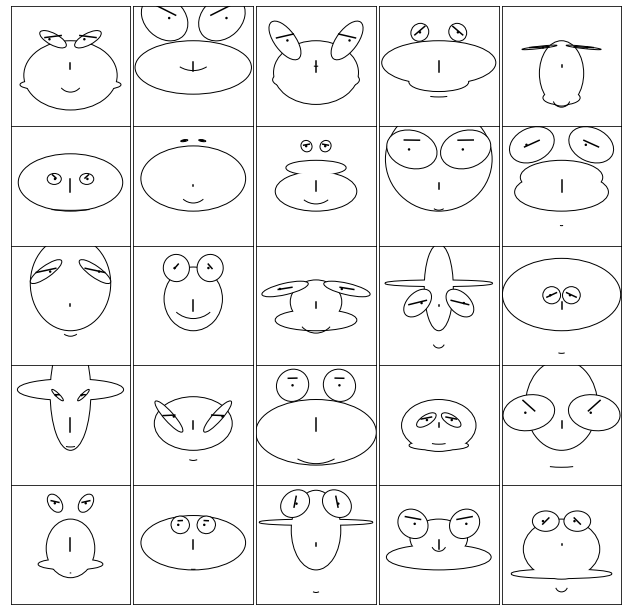

```python
fig = plt.figure(figsize=(11,11))
for i in range(25):
    ax = fig.add_subplot(5,5,i+1,aspect='equal')
    cface(ax, .5, *rand(17))
    ax.axis([-1.2,1.2,-1.2,1.2])
    ax.set_xticks([])
    ax.set_yticks([])

fig.subplots_adjust(hspace=0, wspace=0)
plt.savefig('plot3.png', bbox_inches='tight')
```

### 4) Star plots

**Preprocessing**

```python
footballers_star = footballers.iloc[:,12:17]
footballers_star.head()
```

|  | Acceleration | Aggression | Agility | Balance | Ball control |
| --- | --- | --- | --- | --- | --- |
| 0 | 89 | 63 | 89 | 63 | 93 |
| 1 | 92 | 48 | 90 | 95 | 95 |
| 2 | 94 | 56 | 96 | 82 | 95 |
| 3 | 88 | 78 | 86 | 60 | 91 |
| 4 | 58 | 29 | 52 | 35 | 48 |

**Normalise**

```python
df_max_scaled = footballers_star.copy()
f = (footballers.iloc[:, 12:17].loc[footballers['Position'].isin(['ST', 'GK'])].applymap(lambda v: int(v) if str.isdecimal(v) else np.nan).dropna())
f.head()
for column in df_max_scaled.columns:
    f[column] = f[column]/f[column].abs().max()
f.head()
```

|  | Acceleration | Aggression | Agility | Balance | Ball control |
| --- | --- | --- | --- | --- | --- |
| 0 | 0.927083 | 0.670213 | 0.936842 | 0.663158 | 1.000000 |
| 3 | 0.916667 | 0.829787 | 0.905263 | 0.631579 | 0.978495 |
| 4 | 0.604167 | 0.308511 | 0.547368 | 0.368421 | 0.516129 |
| 5 | 0.822917 | 0.851064 | 0.821053 | 0.842105 | 0.956989 |
| 6 | 0.593750 | 0.404255 | 0.631579 | 0.452632 | 0.451613 |

**Plot**

```python
for pp in range(5):
    dff = pd.DataFrame(dict(
        r = list(map(float, f.iloc[pp, :])) ,
        theta=['Acceleration','Aggression','Agility', 'Balance', 'Ball control']))
    fig = px.line_polar(dff, r='r', theta='theta', line_close=True)
    fig.show()
```

[interactive chart not shown]

**INFERENCE:**  
Here, we have plotted several star plots. To maintain simplicity, I have plotted the star plot for only five different players. The attributes (1) Acceleration, (2) aggression, (3) agility, (4) balance and (5) ball control are compared using this technique. After normalising the variables, the points are identified and plotted on the rays shown above. In doing so, we create a loop that allows us to comprehend each player from five different perspectives. We ideally want a player who excels at all five attributes or shows a good balance between each of these skills. Thus, we can say that player four seems to be most rounded player of them all.

### 5) Pixel oriented representation

**Preprocessing**

```python
final = footballers.iloc[:, [1,7,5]]
final.drop_duplicates()
final = final.iloc[[0,1,2,4,6,7,9], :]
final.head()
```

|  | Age | Club | Overall |
| --- | --- | --- | --- |
| 0 | 32 | Real Madrid CF | 94 |
| 1 | 30 | FC Barcelona | 93 |
| 2 | 25 | Paris Saint-Germain | 92 |
| 4 | 31 | FC Bayern Munich | 92 |
| 6 | 26 | Manchester United | 90 |

**Plot**

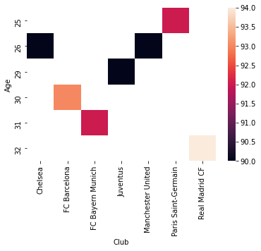

```python
finalplot = final.pivot("Age", "Club", "Overall")
ax = sns.heatmap(finalplot)
```

**INFERENCE:**  
For a given football club, the age of the players are identified and for each corresponding age-club, we encode the overall performance of the player and colour the cell. We see that lighter the colour, better the performance while darker the colour, the worse the performance. We therefore conclude that the player from Real Madrid FC who is 32 has the highest performance value. This data had no time attribute and thus this plot could not be utilised to its maximum capabilities as the main advantage of pixel oriented representation of multivariate data is to depict data ranging multiple years or decades. For this scenario, we see the overall performance with respect to the club and the age of the player.